# Centrality measures in ORBIS Roman transport network

###### graph representation

Antonio Rivero Ostoic

CEDHAR, Aarhus University

jaro@cas.au.dk

24 november 2021

This post concerns network centrality measures from ORBIS transport network:

Scheidel, W. and Meeks, E. (May 2, 2012). ORBIS: The Stanford Geospatial Network Model of the Roman World. Retrieved 14 Sep, 2021, from http://orbis.stanford.edu.

With the HANSON Catalogue:

Hanson, J.W. (2016). Cities Database (OXREP databases). Version 1.0. Accessed (2-11-2021): http://oxrep.classics.ox.ac.uk/databases/cities/. DOI: https://doi.org/10.5287/bodleian:eqapevAn8

And the BARRINGTON Atlas:

Backbone of Hanson database adopting its periodization and classification of settlements.

## Network centrality

Based on two data frames from the [ORBIS transport network](https://htmlpreview.github.io/?https://github.com/sdam-au/R_code/blob/master/HTML/ORBIS%20Roman%20World%20transport%20network%20centrality%20measures.html), there are network centrality measures to define which are the most important or central entities in the Roman World.

```r
head(orbis)
```

```
     id           label      x      y
1 50002   Ad fl. Tigrim 37.325 42.196
2 50209 Iulia Concordia 45.757 12.844
3 50327            Roma 41.892 12.486
4 50319      Praetorium 31.500 15.500
5 50294        Patavium 45.410 11.877
6 50322         Puteoli 40.824 14.122
```

```r
head(orbise)
```

```
  source target      km  days expense type
1  50001  50056  54.539 1.818   1.909 road
2  50001  50100  50.135 1.671   1.755 road
3  50001  50293  65.681 2.189   2.299 road
4  50001  50473 225.368 7.512   7.888 road
5  50002  50275  92.174 3.072   3.226 road
6  50003  50052 109.155 3.639   3.820 road
```

Where the different types of transportation methods are.

```r
levels(orbise$type)
```

```
 [1] "coastal"    "downstream" "fastdown"   "fastup"     "ferry"      "overseas"   "road"
 [8] "slowcoast"  "slowover"   "upstream"
```

### Graph representation

The graph representation is a complement to a cartographical map where some links are easier to see. A graph representation of the ORBIS transport network recorded in `orbisnetLbs` with coordinates in `orbisdcds` is from a force directed layout among the nodes, which reflects a sort of centrality measure in terms of repulsion and attraction forces of nodes.

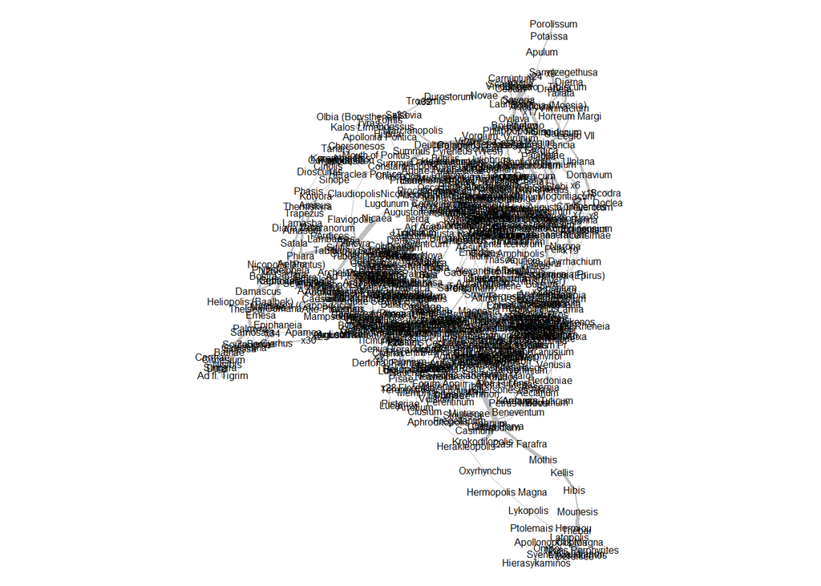

ORBIS transport network

```r
# define scope
scp <- list(ecol=8, pos=0, vcol="white", vcol0=8, fsize=5, cex=.5, rot=180)
# plot valued multigraph with recorded coordinates
multigraph::multigraph(orbisnetLbs, coord=orbisdcds, directed=FALSE, valued=TRUE, scope=scp)
```

It might be useful to contrast the force directed layout of the graph with the placement of prominent nodes in terms of a given centrality measure.

#### Settlement names

Obtain settlement labels and look at the head and tail.

```r
# settlement names with crossing-edges
lbs <- dimnames(orbisnetLbs)[[1]]
```

[output not shown]

[output not shown]

### Centrality measures based on neighbours

The ORBIS transport network data is dichotomized to compute the centrality measures. This is since what is important is solely the existence of connections among settlements, and transportation costs is for extensions to the resulted centrality scores.

```r
# use the minimum non-zero value and above for links
orbisnetd <- multiplex::dichot(orbisnetLbs, c=min(orbisnetLbs[orbisnetLbs>0]))
```

#### Degree centrality

**Degree centrality** measures a node’s importance based on the number of neighbours.

Compute degree centrality by column sum in the adjacency matrix `orbisdnet`. Since the ORBIS transport network is undirected, in-degree and out-degree centralities are indistinguishable, and row sum leads to the same result.

```r
# outdegree centrality from column sums
onetdc <- colSums(orbisnetd)
```

And look at prominent nodes in the graph representing the Roman Empire transportation network.

```r
# top six nodes degree centrality
require("magrittr")
onetdc %>%
  sort(decreasing=TRUE) %>%
  head(10)
```

```
            Delos            Rhodos          Carthago      Ostia/Portus         Lilybaeum
               21                20                11                10                10
             Roma            Paphos    Portus Pachyni           Messana Apollonia-Sozousa
                9                 9                 9                 9                 9
```

```r
# select settlement names for plotting
sel <- head(names(sort(onetdc,decreasing=TRUE)),10)
```

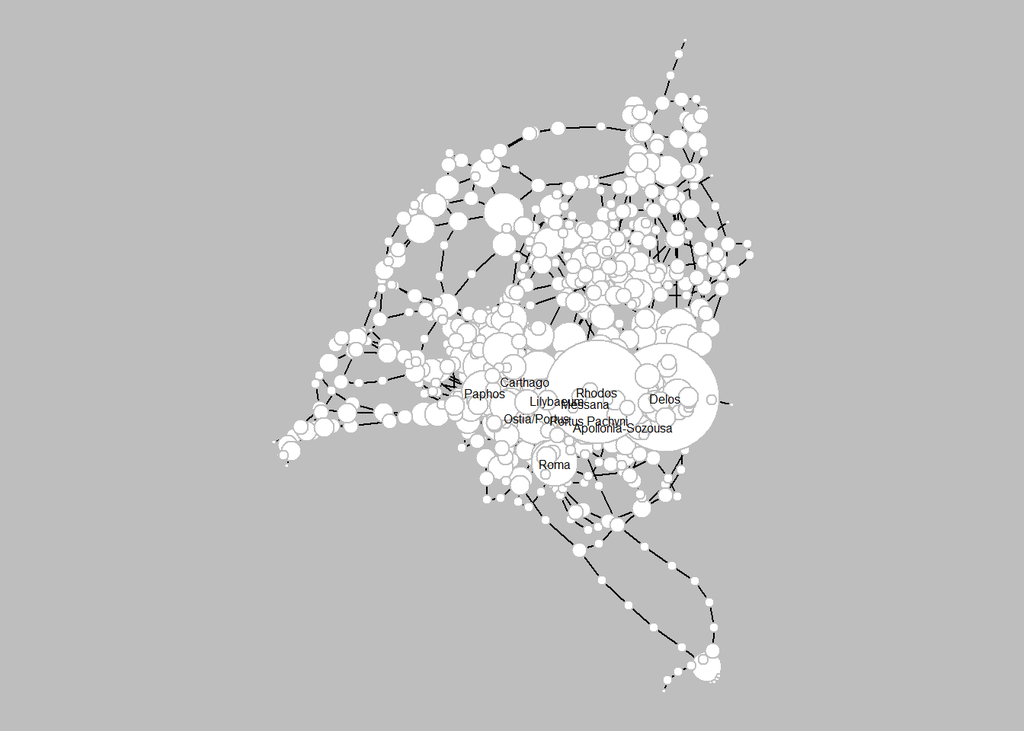

Degree centrality (top 10)

```r
# node sizes according to degree centrality scores
scp <- list(coord=orbisdcds, ecol=1, directed=FALSE, lbs=lbb, pos=0, vcol="white", vcol0=8, fsize=5, rot=180)
multigraph::multigraph(orbisnetLbs, scope=scp, cex=as.vector(onetdc), sel=sel, bg=8)
```

#### Eigenvector centrality

Another centrality measure based on neighbours is **eigenvector centrality**, which measures a node’s importance while considering the number and importance of its neighbours.

To compute eigenvector centrality, use `"igraph"` `R` package

- [https://CRAN.R-project.org/package=igraph](https://cran.r-project.org/package=igraph).

```r
require("magrittr")
onetec <- orbisnetd %>%
  igraph::graph.adjacency() %>%
  igraph::eigen_centrality() %>%
  use_series("vector") %>%
  as.vector(mode="list") %>%
  unlist()
```

Prominent nodes in terms of eigenvector centrality.

```r
# top ten nodes eigenvector centrality
require("magrittr")
onetec %>%
  sort(decreasing=TRUE) %>%
  head(10)
```

```
     Rhodos       Delos       Samos         Kos     Ephesus      Myndos  Astypaleia     Amorgos
  1.0000000   0.9525685   0.5881245   0.5831718   0.5138541   0.4343745   0.4143912   0.4140000
Sounion Pr.    Selinous
  0.3968902   0.3706105
```

```r
# select settlement names for plotting
sel <- head(names(sort(onetec,decreasing=TRUE)),10)
```

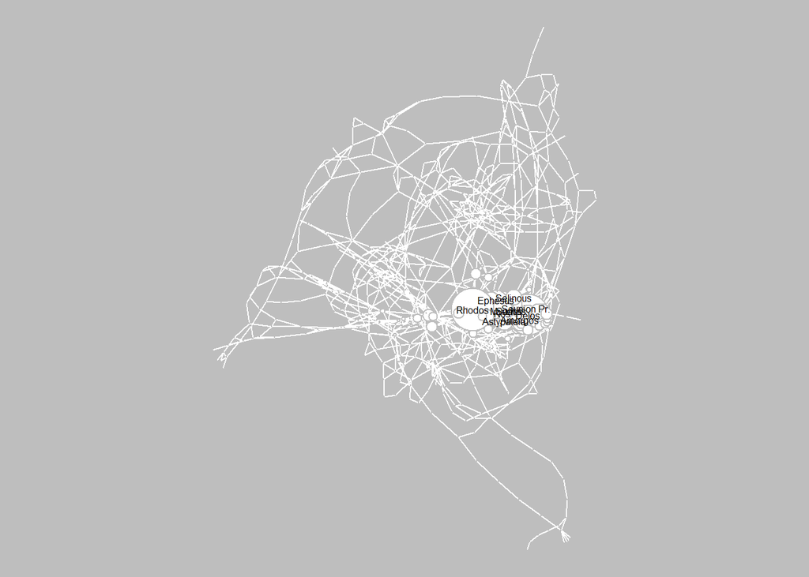

Eigenvector centrality (top 10)

```r
# scale-up node sizes for better visibility
scp <- list(directed=FALSE, pos=0, ecol="white", vcol="white", vcol0=8, fsize=5, rot=180, bg=8)
multigraph::multigraph(orbisnetLbs, coord=orbisdcds, scope=scp, lbs=lbb, cex=as.vector(onetec)*5L, sel=sel)
```

## Settlements

The two most central settlements in terms of degree and eigenvector centrality are ports in the Aegean Sea.

### DELOS

(Greek Δῆλος)

**Achaia**, port in archipelago Cyclades, Aegean Sea.

Between 900 BC and 100 AD (or around the 8th century AD (Dodd, 2020)).

Birthplace of Apollo and Artemis.

Sacred Harbour and Sanctuary of Zeus in Mount Kynthos as one of three conical mounds.

Proximal to Pergamum that was the leading city of Roman province of Asia, in the coast of Asia Minor, and a major pilgrim centre for the Greek god of medicine Asclepius.

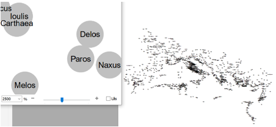

According to Hanson catalogue, Delos is geographically adjacent to Paros and Naxus.

### RHODOS

(Greek Ῥόδος, *Rhodus in Hanson*)

**Asia**, largest of the Dodecanese islands, Aegean Sea.

From 408 BC

Colossus of Rhodes, a massive statue of the Greek god of the sun Helios, and The Acropolis with the Temple of Apollo.

Strong commercial ties and alliance with the Ptolemies in Egypt.

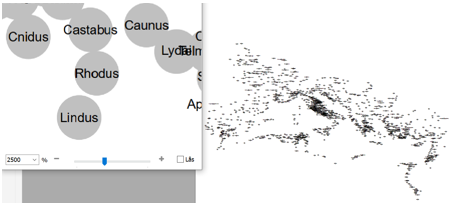

According to Hanson catalogue, Rhodos is geographically adjacent to Lindus, Cnidus, Caunus, Lydai?, and Castabus.

### CARTHAGO

(Phoenician for “new town”)

**Africa Proconsularis**, port in the north coast of African continent.

By tradition, founded by the Phoenicians 814 BC.

Important trade centre in the western Mediterranean Sea.

### SAMOS

(Greek Σάμος)

**Asia**, island in the eastern of the Aegean Sea.

From 6th century BC

School of sculptors, architects, and manufacture of pottery.

### Centrality measures based on shortest path

Besides neighbours, centrality measures on networks are also based on geodesic or shortest path, which applies on a binary network.

#### Betweenness centrality

**Betweenness centrality** measures the fraction of shortest paths between all other nodes that run through the node.

```r
# compute betweenness centrality
require("magrittr")
onetbc <- orbisnetd %>%
  igraph::graph.adjacency() %>%
  igraph::betweenness() %>%
  as.vector(mode="list") %>%
  unlist()
```

Then look at prominent nodes in terms of betweenness centrality.

```r
# top ten nodes betweenness centrality
require("magrittr")
onetbc %>%
  sort(decreasing=TRUE) %>%
  head(10)
```

```
           Messana         Alexandria             Rhodos              Gades  Apollonia-Sozousa
         204303.79          184557.32          133234.20          108498.27           73140.05
           Olisipo    Sallentinum Pr. Flavium Brigantium   Acroceraunia Pr.          Lilybaeum
          69337.27           64974.03           63538.38           61357.27           58087.15
```

What is remarkable with betweenness centrality and the other measures based on shortest path is that the most prominent settlements are all ports within the Roman World and constitute strategic communication points having both maritime and terrestrial routes from which many other nodes depend on them for transportation purposes.

Centrality measures based on shortest path highlights nodes top centrality scores in the graph representations.

```r
# select settlement names for plotting
sel <- head(names(sort(onetbc,decreasing=TRUE)),10)
```

```r
# new labels with selected nodes
lbb <- rep("",length(onetbc)); vec <- vector()
for(i in seq_len(length(sel))) vec <- append(vec, which(lbs%in%sel[i]))
lbb[vec] <- sel
```

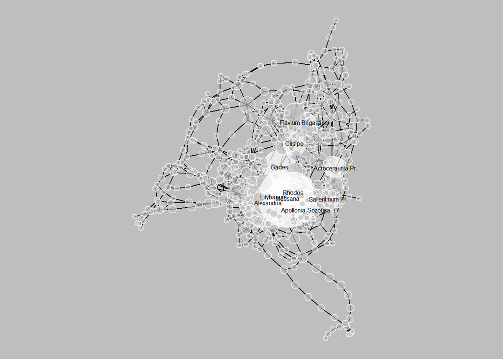

Betweenness centrality (top 10)

```r
# clustering for node colors
ccl <- vector(length=length(lbb)); ccl[which(lbb=="")] <- 1L
scp <- list(directed=FALSE, pos=0, ecol=1, vcol0="white", vcol=c("white",8), clu=ccl, fsize=5, rot=180, bg=8)
# node sizes with centrality scores
multigraph::multigraph(orbisnetLbs, coord=orbisdcds, scope=scp, cex=as.vector(onetbc), sel=sel)
```

#### Closeness centrality

**Closeness centrality** is the reciprocal of average shortest path distance.

(Eccentricity centrality takes the maximum geodesic path distance)

```r
# compute closeness centrality
require("magrittr")
onetcc <- orbisnetd %>%
  igraph::graph.adjacency() %>%
  igraph::closeness() %>%
  as.vector(mode="list") %>%
  unlist()
```

Then look at high score nodes in terms of closeness centrality.

```r
# 10 nodes with highest closeness scores
require("magrittr")
onetcc %>%
  sort(decreasing=TRUE) %>%
  head(10) %>%
  unlist()
```

```
          Messana        Alexandria             Gades Apollonia-Sozousa         Lilybaeum
     0.0002347418      0.0002275313      0.0002237136      0.0002176752      0.0002171081
           Rhodos    Portus Pachyni       Ichthys Pr.           Caralis            Regium
     0.0002145923      0.0002118195      0.0002103492      0.0002103049      0.0002101282
```

As with betweenness centrality that is also based on shortest path distance, the most prominent settlements in terms of closeness centrality are all ports within the Roman World. However, the values tend to span a rather small dynamic range from smallest to largest, which means that interpretation is not straightforward.

```r
# select settlement names for plotting
sel <- head(names(sort(onetcc,decreasing=TRUE)),10)
```

```r
# new labels with selected nodes
lbb <- rep("",length(onetcc)); vec <- vector()
for(i in seq_len(length(sel))) vec <- append(vec, which(lbs%in%sel[i]))
lbb[vec] <- sel
```

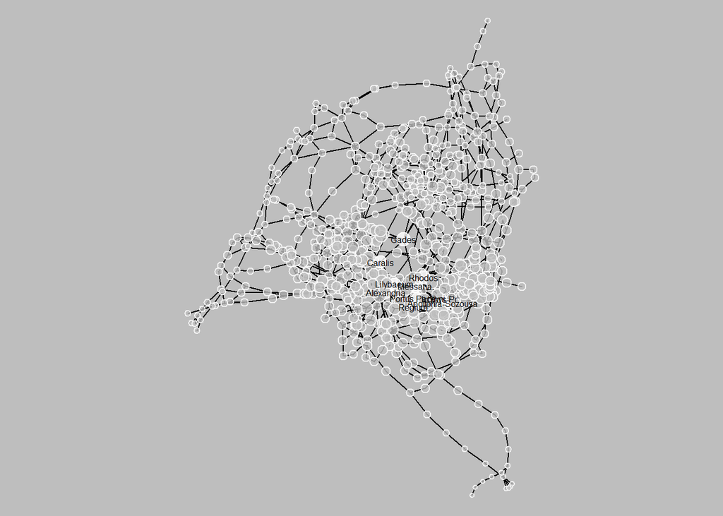

Closeness centrality (top 10)

```r
# clustering for node colors
ccl <- vector(length=length(lbb)); ccl[which(lbb=="")] <- 1L
scp <- list(directed=FALSE, pos=0, ecol=1, vcol0="white", vcol=c("white",8), clu=ccl, fsize=5, rot=180, bg=8)
# scale-up node sizes for better visibility
multigraph::multigraph(orbisnetLbs, coord=orbisdcds, scope=scp, cex=as.vector(onetcc)*8000L, sel=sel)
```

## Settlements

### MESSANA

(Sicilian MISSINA, from ancient Greek city Μεσσήνη)

**Sicily**, port in the Mediterranean, between Tyrrhenian Sea and Ionian Sea.

Proximal to Italian peninsula (5 km).

From 730 BC.

With a pharos, base for Roman military activity.

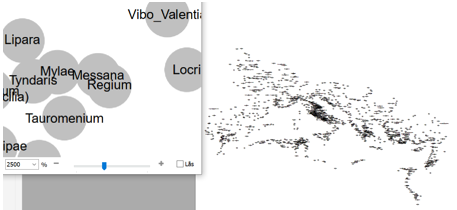

According to Hanson catalogue, Messana is geographically adjacent to Regium, Mylae, and by sea with Locri and Vibo Valentia in the Italian peninsula.

### ALEXANDRIA

(Greek Ἀλεξάνδρεια *not to be confused with Alexandria Troas in Asia Minor*)

**Aegyptus**, port in the African continent.

From Ptolemaic dynasty

One of the largest city in the ancient world connecting the Mediterranean Sea and the Red Sea ruled by a complex Greek bureaucracy.

Intellectual and cultural centre (later on flocked to Rome)

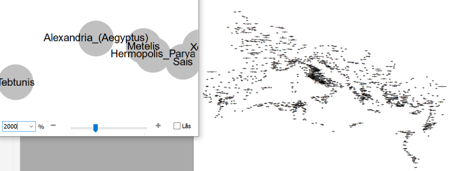

According to Hanson catalogue, Alexandria is geographically adjacent to Metelis and Tebtunis.

### GADES

(*Urba Iulia Gaditana*)

**Baetica**, port in the Iberian peninsula

Established between 8th and 10th century BC.

Old Carthaginian colony disputed with the Phoenicians.

Strategic point to control of the western Mediterranean Sea.

## Centrality measures tasks

Water transport was a key element of Roman military activity and in the Roman economy as a whole.

- Use the different kinds of routes to assess centralities per transportation type

For most prominent settlements with degree and betweenness centrality in the RE transport network.

- Obtain coordinates
- Complete time-spans
- Elaborate on narratives
  - prominence (centrality scores)
  - antagonism (negative ties in history)

## Valued networks

For a valued or weighted version of this network, we create a valued edge list in `orbisv` with send, receive, and tie weights.

```r
orbisv <- orbise[,c(1,2,5)]
tail(orbisv)
```

```
     source target expense
2203  50800  50779   0.059
2204  50800  50783   0.056
2205  50801  50573   0.109
2206  50801  50582   0.074
2207  50801  50777   0.033
2208  50801  50785   0.034
```

#### Centrality measures in valued networks

Different centrality measures for weighted networks are found in `"tnet"` package where argument `alpha` is a tuning parameter that serves to combine node’s degree and edge’s strength. An alpha value of zero ignores edges’ weights; i.e. binarize the network, while an alpha value of one disregards nodes’ number of incident edges.

The following examples are for three centrality measures spliting equally node degree and edge strength in the weighted system.

```r
# degree centrality valued
tail(tnet::degree_w(net=orbisv, measure=c("degree","output","alpha"), alpha=0.5))
```

```
          node degree output     alpha
[50796,] 50796      3  1.270 1.9519221
[50797,] 50797      2  0.080 0.4000000
[50798,] 50798      2  0.061 0.3492850
[50799,] 50799      2  0.095 0.4358899
[50800,] 50800      4  0.165 0.8124038
[50801,] 50801      4  0.250 1.0000000
```

```r
# betweenness centrality valued
tail(tnet::betweenness_w(net=orbisv, alpha=0.5))
```

```
          node betweenness
[50796,] 50796        1352
[50797,] 50797           0
[50798,] 50798           0
[50799,] 50799           0
[50800,] 50800           0
[50801,] 50801         120
```

```r
# closeness centrality valued
tail(tnet::closeness_w(net=orbisv, alpha=0.5))
```

```
        node    closeness  n.closeness
[673,] 50796 1.298232e-04 1.917624e-07
[674,] 50797 9.325457e-05 1.377468e-07
[675,] 50798 7.390118e-05 1.091598e-07
[676,] 50799 1.105484e-04 1.632915e-07
[677,] 50800 7.850528e-05 1.159605e-07
[678,] 50801 9.979916e-05 1.474138e-07
```

#### Eigenvector centrality in valued networks

There is no support in `"tnet"` package to compute *eigenvector centrality* scores for valued networks. With an unclear documentation, `"igraph"` package has a `weights` argument in `eigen_centrality()` function to run eigenvector centrality for weighted networks. Since `"tnet"` requires `"igraph"`, however, the implementation of eigenvector centrality for valued networks is not straightforward.

¨

### See also

- [ORBIS Roman World transport network centrality measures (part I)](https://htmlpreview.github.io/?https://github.com/sdam-au/R_code/blob/master/HTML/ORBIS%20Roman%20World%20transport%20network%20centrality%20measures.html)
- [Plotting Roman Empire transport network](https://sdam-au.github.io/sdam/articles/TransportNetwork.html)
- [Plotting ancient Roman provinces and regions](https://sdam-au.github.io/sdam/articles/RomanProvs.html)
- [Re-encoding Greek characters from ‘EDH’ dataset](https://sdam-au.github.io/sdam/articles/Encoding.html)
- [`"sdam"` manual](https://github.com/mplex/cedhar/blob/master/typesetting/reports/sdam.pdf)
- [Social Dynamics and complexity in the Ancient Mediterranean Project](https://sdam-au.github.io/sdam-au/)